# Common R Syntax

Yuan Chang Leong

I wanted to make explicit some of the common pattern structures of code that we’ve been using again and again in the class. I’ll add to them as I think of more. For each, I’ll first write in comments the “general syntax”, and then an example of it.

Click [here](https://htmlpreview.github.io/?https://github.com/nataliavelez/RWorkshop/blob/master/Resources/Common_R.html) to see knitted version of the file

### Loading libraries and installing packages

```r
# Installing packages: install.packages('<name of package>')
# install.packages('dplyr') # Commenting this out so that it will knit

# Load libraries: library(<name of library>)
library(tidyr)
library(dplyr)
```

```r
library(NHANES)
library(ggplot2)
```

### Manipulating the dataframe

This includes selecting columns, filtering rows, creating new variables.

```r
# Try to always remember the same pattern
# <data.frame> = <data.frame> %>%
#   select(<columns to keep>) %>%
#   filter(<logical statement to determine which row to keep>) %>%
#   mutate(<new variable> = XXXX)

NHANES_adult = NHANES %>%
  select(Age, Smoke100, Height) %>%
  filter(Age > 17 & !is.na(Smoke100) & !is.na(Height)) %>%
  mutate(HeightInInches = Height * 0.39)

head(NHANES_adult)
```

```
## # A tibble: 6 x 4
##     Age Smoke100 Height HeightInInches
##   <int> <fct>     <dbl>          <dbl>
## 1    34 Yes         165           64.2
## 2    34 Yes         165           64.2
## 3    34 Yes         165           64.2
## 4    49 Yes         168           65.7
## 5    45 No          167           65.0
## 6    45 No          167           65.0
```

### Summarizing the dataframe

You do this when you want to aggregate (i.e. summarize) over certain variables. Again the syntax is usually near-identical.

Another trick to remember - group_by is almost ALWAYS followed by summarise

```r
# <summary dataframe> = <full dataframe> %>%
#    group_by(<variable to group by>) %>%
#    summarise(<name of summary variable = <name of function>(<name of variable>))

# The common functions that go with summarize include, n() which counts, mean() which take the mean, var() which takes the variance, sd() which takes the sd:

data_summary = NHANES_adult %>%
  group_by(Smoke100) %>%
  summarise(n = n(),
            meanHeight = mean(Height),
            varHeight = var(Height),
            sdHeight = sd(Height))

head(data_summary)
```

```
## # A tibble: 2 x 5
##   Smoke100     n meanHeight varHeight sdHeight
##   <fct>    <int>      <dbl>     <dbl>    <dbl>
## 1 No        3997        168     108      10.4
## 2 Yes       3185        170      90.9     9.53
```

### Writing a function

```r
#<name of function> = function(<input1>, <input2>, ....){
# what you want the function to do
#}

sumOf2Numbers = function(x,y){
  z = x + y
  return(z)
}

thisSum = sumOf2Numbers(3,4)
thisSum
```

```
## [1] 7
```

```r
# You can also set default values for the inputs:
sumOf2Numbers_wDefaults = function(x = 1 ,y = 2){
  z = x + y
  return(z)
}

# if you don't give it any inputs, the function will use the default values
thatSum = sumOf2Numbers_wDefaults()
thatSum
```

```
## [1] 3
```

```r
# But you can overwrite the default
# The following line of code would add 4 to the default value of x.
anotherSum = sumOf2Numbers_wDefaults(y = 4)
anotherSum
```

```
## [1] 5
```

## Statistical Tests

### t-tests

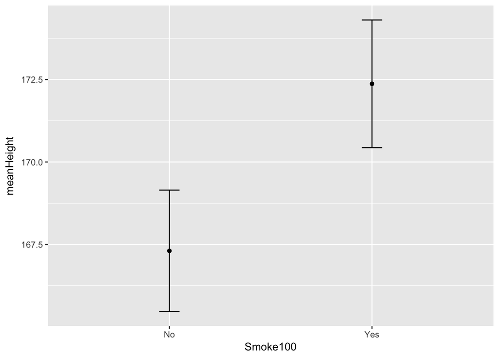

```r
# Syntax of a t-test:
# <output name> = t.test(<Dependent Variable> ~ <Independent Variable>, data = <name of input data frame>, alternative = "XXX")

# First let's take a sample of 200 from NHANES_adult
set.seed(4)
NHANES_sample = sample_n(NHANES_adult,200)

# Before running the t-test, you should try to plot the means of the two groups, with error bars indicating 95% confidence intervals
dataSummary = NHANES_sample %>%
  group_by(Smoke100) %>%
  summarize(n=n(),
            meanHeight=mean(Height),
            varHeight=var(Height),
            sdHeight = sd(Height),
            crit_val_lower = qt(.025, n - 1),
            crit_val_upper = qt(.975, n - 1),
            ci.lower=meanHeight+(sqrt(varHeight)*crit_val_lower)/sqrt(n),
            ci.upper=meanHeight+(sqrt(varHeight)*crit_val_upper)/sqrt(n))

ggplot(dataSummary, aes(x=Smoke100, y = meanHeight)) +
    geom_point() +
    geom_errorbar(aes(ymin = ci.lower, ymax = ci.upper), width = 0.1, size = 0.5)
```

```r
ttestResult = t.test(Height ~ Smoke100, data = NHANES_sample, alternative = "two.sided")
ttestResult
```

```
##
##  Welch Two Sample t-test
##
## data:  Height by Smoke100
## t = -3.7641, df = 191.81, p-value = 0.0002221
## alternative hypothesis: true difference in means is not equal to 0
## 95 percent confidence interval:
##  -7.717444 -2.410397
## sample estimates:
##  mean in group No mean in group Yes
##          167.3062          172.3701
```

A two-tailed t-tests shows that the mean height of smokers (M = 172.4, SD = 9.90) is statistically greater than the mean height of non-smokers (M = 167.3, SD = 9.08); t(192) = -3.76, p = 0.0002). This supports our hypothesis that smokers are taller than non-smokers.

### Correlation

To measure the relationship between two **continuous** variables, we can calculate the correlation between them. In the slides, I used the function cor(), which calculates the correlation coefficient between the two variables. But cor() doesn’t tell you if the correlation is statistically significant.

For that, we can use use the function cor.test() which does a t-test on the r value to see if it’s significantly different from 0.

By default, these functions all run pearson’s correlation. As you’ll learn later in the quarter, there are actually different types of correlation (Kendall, Spearman) but Pearson is most commonly used.

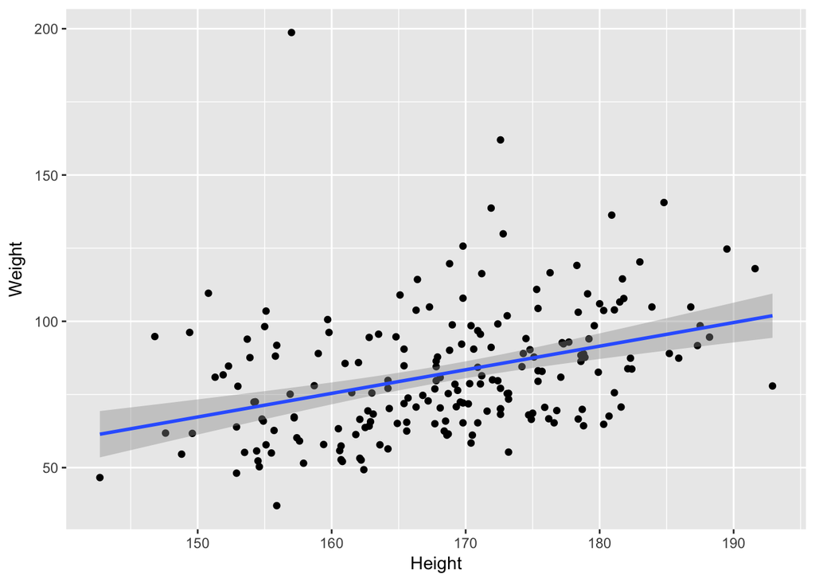

```r
# Create a new sample with weight information
NHANES_adultWeight = NHANES %>%
  select(Age, Smoke100, Height, Weight) %>%
  filter(Age > 17 & !is.na(Smoke100) & !is.na(Height) & !is.na(Weight))

NHANES_sampleWeight = sample_n(NHANES_adultWeight,200)

# Syntax for cor: r = cor(<Variable1>, <Variable2>)
# Syntax for cor.test: r_sig = cor.test(<Variable1>, <Variable2>)

# Let's look at the correlation coefficient between Height and Weight in NHANES_sample. Before computing the correlation, let's first visualize the relationship between the two:
ggplot(NHANES_sampleWeight, aes(x = Height, y = Weight)) +
  geom_point() +
  geom_smooth(method = lm)
```

```r
# Let's first use cor() to calculate the correlation coefficient
r = cor(NHANES_sampleWeight$Height, NHANES_sampleWeight$Weight)
r
```

```
## [1] 0.3670781
```

```r
# Now we use cor.test()
r_sig = cor.test(NHANES_sampleWeight$Height, NHANES_sampleWeight$Weight)
r_sig
```

```
##
##  Pearson's product-moment correlation
##
## data:  NHANES_sampleWeight$Height and NHANES_sampleWeight$Weight
## t = 5.5529, df = 198, p-value = 8.964e-08
## alternative hypothesis: true correlation is not equal to 0
## 95 percent confidence interval:
##  0.2405900 0.4813067
## sample estimates:
##       cor
## 0.3670781
```

There is a statistically significant positive correlation between height and weight of the individuals in NHANES (r = 0.37, p = 8.96e-08).

### Chi-Square Test

```r
NHANES_SmokeGender = NHANES %>%
  select(Smoke100, Gender) %>%
  filter(!is.na(Smoke100) & !is.na(Gender))

# Step 1: Summarize the data to get the counts in each cell
dataSummary_SmokeGender = NHANES_SmokeGender %>%
  group_by(Smoke100,Gender) %>%
  summarize(n=n())
dataSummary_SmokeGender
```

```
## # A tibble: 4 x 3
## # Groups: Smoke100 [?]
##   Smoke100 Gender     n
##   <fct>    <fct>  <int>
## 1 No       female  2281
## 2 No       male    1743
## 3 Yes      female  1402
## 4 Yes      male    1809
```

```r
# Step 2: "Spread" the dataframe into a contingency table
dataSummary_SmokeGender = dataSummary_SmokeGender %>%
  spread(Smoke100, n)
dataSummary_SmokeGender
```

```
## # A tibble: 2 x 3
##   Gender    No   Yes
## * <fct>  <int> <int>
## 1 female  2281  1402
## 2 male    1743  1809
```

```r
# Step 3: Run chisq.test
chisq.test(dataSummary_SmokeGender[,2:3])
```

```
##
##  Pearson's Chi-squared test with Yates' continuity correction
##
## data:  dataSummary_SmokeGender[, 2:3]
## X-squared = 120.66, df = 1, p-value < 2.2e-16
```

### Linear Regression

Can be used to examine the effect of multiple independent variables on one dependent variable. Dependent variable has to be continuous (e.g., height), but the independent variables can be categorical (e.g., smoke, gender) or continuous (e.g., age).

```r
set.seed(3)
NHANES_SmokeGenderAge = NHANES %>%
  select(Smoke100, Gender, Age, Height) %>%
  filter(!is.na(Smoke100) & !is.na(Gender) & !is.na(Age) & !is.na(Height)) %>%
  sample_n(size = 200)

# Syntax: summary(lm(<DV> ~ <IV1> + <IV2> + ..., data = <data.frame>))
# Let's run a series of lm to predict height from smoke, gender, age

# Let's start by looking at the effect of Smoke on Height
summary(lm(Height ~ Smoke100, NHANES_SmokeGenderAge))
```

```
##
## Call:
## lm(formula = Height ~ Smoke100, data = NHANES_SmokeGenderAge)
##
## Residuals:
##      Min       1Q   Median       3Q      Max
## -27.1731  -7.4973  -0.4698   7.0294  29.1302
##
## Coefficients:
##             Estimate Std. Error t value Pr(>|t|)
## (Intercept)  167.073      1.070 156.079   <2e-16 ***
## Smoke100Yes    3.397      1.545   2.198   0.0291 *
## ---
## Signif. codes:  0 '***' 0.001 '**' 0.01 '*' 0.05 '.' 0.1 ' ' 1
##
## Residual standard error: 10.92 on 198 degrees of freedom
## Multiple R-squared:  0.02383,    Adjusted R-squared:  0.0189
## F-statistic: 4.833 on 1 and 198 DF,  p-value: 0.02908
```

```r
# This analysis is in fact mathematically equivalent to the t-test assuming equal variance
t.test(Height ~ Smoke100, NHANES_SmokeGenderAge, var.equal = TRUE)
```

```
##
##  Two Sample t-test
##
## data:  Height by Smoke100
## t = -2.1985, df = 198, p-value = 0.02908
## alternative hypothesis: true difference in means is not equal to 0
## 95 percent confidence interval:
##  -6.4435650 -0.3498645
## sample estimates:
##  mean in group No mean in group Yes
##          167.0731          170.4698
```

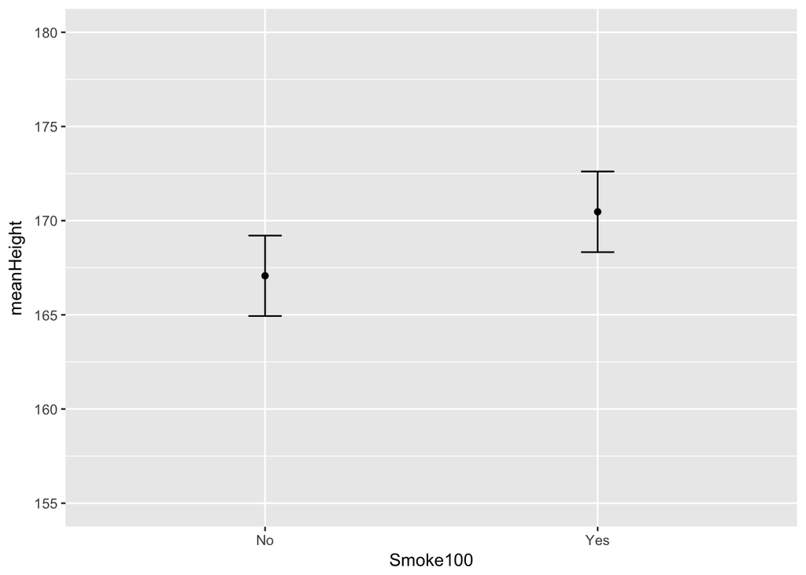

```r
# Plot
dataSummary = NHANES_SmokeGenderAge %>%
  group_by(Smoke100) %>%
  summarize(n=n(),
            varHeight=var(Height),
            meanHeight=mean(Height),
            ci.upper=meanHeight+(sqrt(varHeight)*1.96)/sqrt(n),
            ci.lower=meanHeight-(sqrt(varHeight)*1.96)/sqrt(n))

ggplot(dataSummary, aes(x=Smoke100, y = meanHeight)) +
  geom_point() +
  geom_errorbar(aes(ymin = ci.lower, ymax = ci.upper), width = 0.1, size = 0.5) +
  coord_cartesian(ylim=c(155,180))
```

```r
# Let's now look at the effect of Gender on Height
summary(lm(Height ~ Gender, NHANES_SmokeGenderAge))
```

```
##
## Call:
## lm(formula = Height ~ Gender, data = NHANES_SmokeGenderAge)
##
## Residuals:
##      Min       1Q   Median       3Q      Max
## -21.5538  -4.9975  -0.6538   5.4650  22.7213
##
## Coefficients:
##             Estimate Std. Error t value Pr(>|t|)
## (Intercept) 161.4538     0.7661   210.8   <2e-16 ***
## Gendermale   15.4249     1.1174    13.8   <2e-16 ***
## ---
## Signif. codes:  0 '***' 0.001 '**' 0.01 '*' 0.05 '.' 0.1 ' ' 1
##
## Residual standard error: 7.887 on 198 degrees of freedom
## Multiple R-squared:  0.4904, Adjusted R-squared:  0.4878
## F-statistic: 190.5 on 1 and 198 DF,  p-value: < 2.2e-16
```

```r
# And the effect of Gender and Smoke on Height in the same model
summary(lm(Height ~ Gender + Smoke100, NHANES_SmokeGenderAge))
```

```
##
## Call:
## lm(formula = Height ~ Gender + Smoke100, data = NHANES_SmokeGenderAge)
##
## Residuals:
##     Min      1Q  Median      3Q     Max
## -21.016  -5.226  -0.439   5.079  22.142
##
## Coefficients:
##             Estimate Std. Error t value Pr(>|t|)
## (Intercept) 160.9160     0.8969  179.41   <2e-16 ***
## Gendermale   15.2460     1.1273   13.52   <2e-16 ***
## Smoke100Yes   1.2955     1.1262    1.15    0.251
## ---
## Signif. codes:  0 '***' 0.001 '**' 0.01 '*' 0.05 '.' 0.1 ' ' 1
##
## Residual standard error: 7.881 on 197 degrees of freedom
## Multiple R-squared:  0.4938, Adjusted R-squared:  0.4887
## F-statistic: 96.09 on 2 and 197 DF,  p-value: < 2.2e-16
```

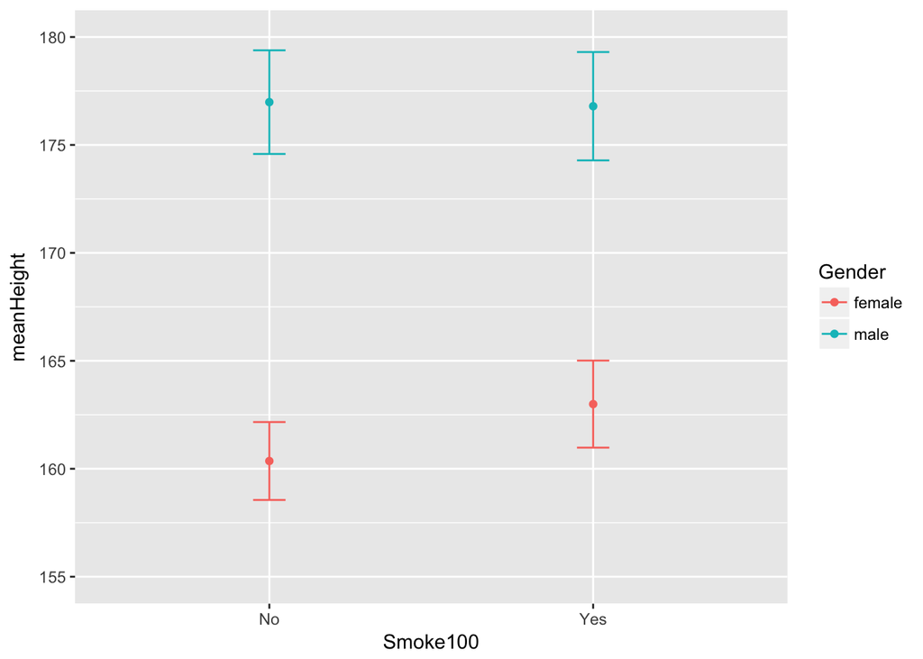

```r
# Plot
dataSummary = NHANES_SmokeGenderAge %>%
  group_by(Smoke100, Gender) %>%
  summarize(n=n(),
            varHeight=var(Height),
            meanHeight=mean(Height),
            ci.upper=meanHeight+(sqrt(varHeight)*1.96)/sqrt(n),
            ci.lower=meanHeight-(sqrt(varHeight)*1.96)/sqrt(n))

ggplot(dataSummary, aes(x=Smoke100, y = meanHeight, color = Gender)) +
    geom_point() +
    geom_errorbar(aes(ymin = ci.lower, ymax = ci.upper), width = 0.1, size = 0.5)+
  coord_cartesian(ylim=c(155,180))
```

### Randomization Test

We went over Randomization Test in Week 7’s section, so I won’t go over it again here. Briefly, the steps are as follows:  
1. Compute the statistic of interest (e.g., diffHeight from NHANES_sample) 2. Write a function that shuffles the labels, and recomputes the statistic of interest from the shuffled data 3. Run the function many times (~5000) 4. Compare the statistic of interest from the sample with the distribution obtained from running the function 5000 times.

```r
# Calculate diff Height from the sample
dataSummary = NHANES_sample %>%
  group_by(Smoke100) %>%
  summarize(meanHeight=mean(Height))

diffHeight=diff(dataSummary$meanHeight)

# Write function that shuffles the labels
shuffleMeanNHANES = function(df){
  df = df %>% mutate(Smoke100shuffled = sample(Smoke100))

  means = df %>%
    group_by(Smoke100shuffled) %>%
    summarize(mean=mean(Height))
  return(diff(means$mean))
}

# Run the function many times
shuffleDist = replicate(5000,shuffleMeanNHANES(NHANES_sample))

# Compare original diffHeight to null distribution
pValue = mean(shuffleDist>= diffHeight)
pValue
```

```
## [1] 2e-04
```

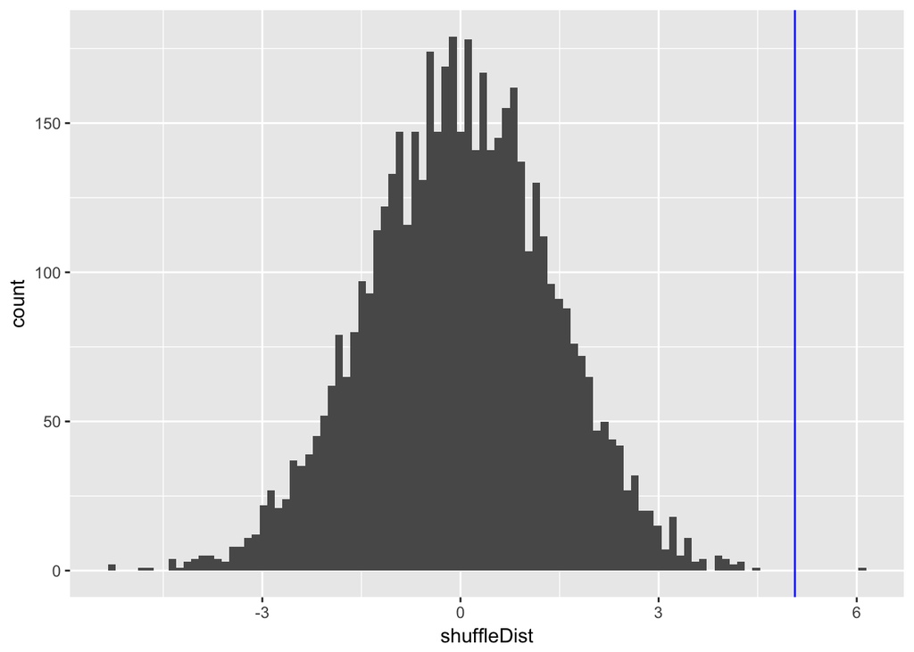

```r
ggplot(data.frame(shuffleDist),aes(shuffleDist)) +
  geom_histogram(bins=100) +
  geom_vline(xintercept = diffHeight,color='blue')
```

### Plotting

The syntax for ggplot is also usually very systematic as well:

```r
# ggplot(<data.frame>, aes(<aesthetic mapping, which depends on plot type>)) +
#     geom_XXXX(<settings of the plot>)
```

Note that ggplot only takes in data.frames as inputs. If you have a vector, you have to convert it into a dataframe using data.frame() or as.data.frame().

#### Histogram

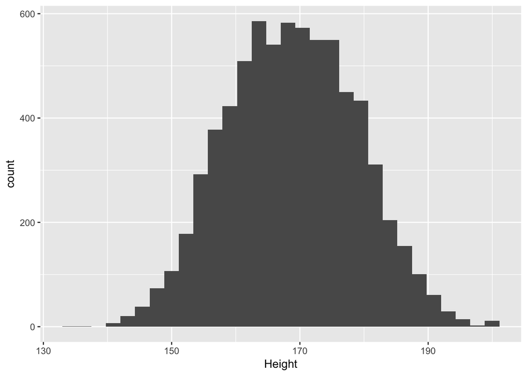

```r
# Again, try to see if you fit the following format:
# ggplot(<data.frame>, aes(<aes mapping, which depends on plot type>)) +
#     geom_XXXX(<settings of the plot>)

# Histogram
ggplot(NHANES_adult, aes(Height)) +
  geom_histogram()
```

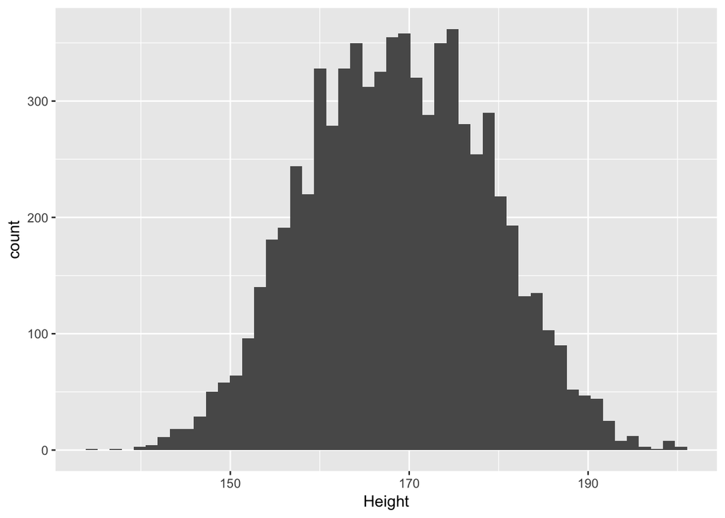

```r
# what if you wanted to set the number of bins (how many bins there are)?
ggplot(NHANES_adult, aes(Height)) +
  geom_histogram(bins = 50)
```

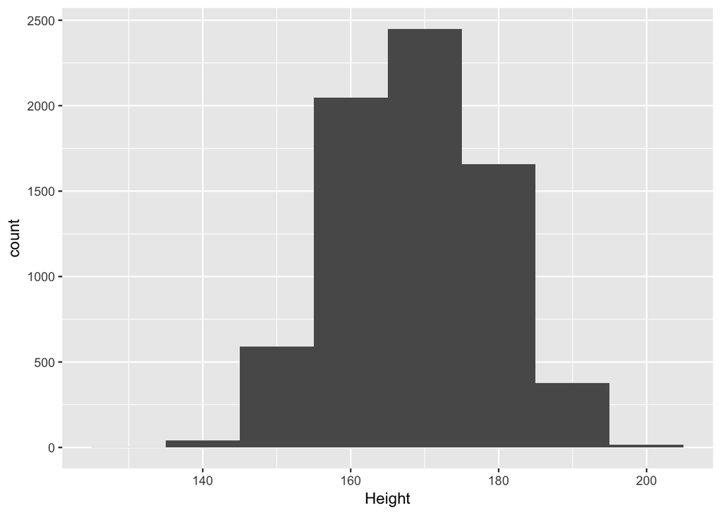

```r
# what if you wanted to set the bin width (how big is each bin)?
ggplot(NHANES_adult, aes(Height)) +
  geom_histogram(binwidth = 10)
```

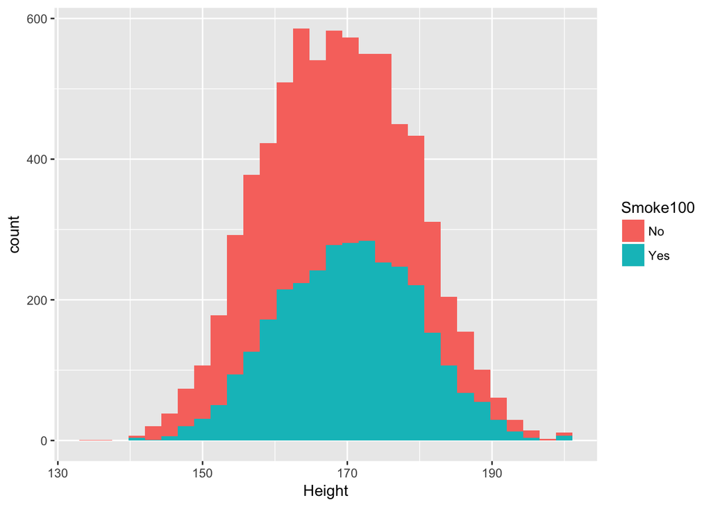

```r
# what if you wanted different colors of Smoke100
ggplot(NHANES_adult, aes(Height, fill = Smoke100)) +
  geom_histogram()
```

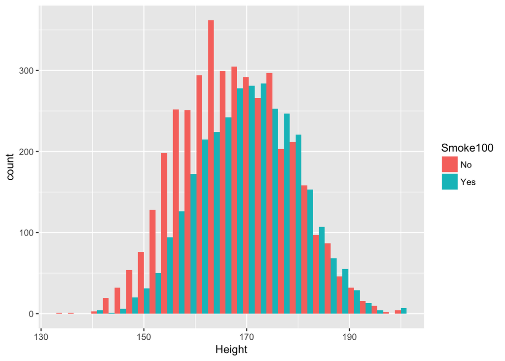

```r
# The above plot will "stack" Smokers and Non-smokers on top of one another by default
# Instead, let's try to put them side by side
ggplot(NHANES_adult, aes(Height, fill = Smoke100)) +
  geom_histogram(position = 'dodge')
```

I’ll try to add the following when I get a chance: Line plots, Bar plots